# CoMut Plot Example

This notebook demonstrates the CoMut plot, a sample-centric multi-panel visualization that integrates multiple genomic and clinical features. Columns represent individual samples, and rows represent different data tracks (mutation burden, signatures, purity, gene mutations, copy number alterations, etc.).

For detailed documentation, see the [CoMut Plot API Reference](https://luisruimor.github.io/pyMut/api/Visualization/comut_plot/).

## Load Data

Load the MAF file and create a `PyMutation` object.

```python
from pyMut.input import read_maf

maf_path = "../../../src/pyMut/data/examples/MAF/TCGA_test.maf"
print(f'📂 Loading file: {maf_path}')

# Read the MAF file (CoMut filtering is applied automatically during visualization)
py_mutation = read_maf(maf_path, assembly="37", consolidate_variants=False)
```

from pyMut.input import read_maf maf_path = "../../../src/pyMut/data/examples/MAF/TCGA_test.maf" print(f'📂 Loading file: {maf_path}') # Read the MAF file (CoMut filtering is applied automatically during visualization) py_mutation = read_maf(maf_path, assembly="37", consolidate_variants=False)

```
2026-10-13 14:29:25,451 | INFO | pyMut.input | Starting MAF reading: ../../../src/pyMut/data/examples/MAF/TCGA_test.maf
```

```
2026-10-13 14:29:25,453 | INFO | pyMut.input | Loading from cache: ../../../src/pyMut/data/examples/MAF/.pymut_cache/TCGA_test_9f3525e955bd76c7.parquet
```

```
📂 Loading file: ../../../src/pyMut/data/examples/MAF/TCGA_test.maf
```

```
2026-10-13 14:29:27,670 | INFO | pyMut.input | Cache loaded successfully in 2.22 seconds
```

## Configure Plot Settings

Enable high-quality rendering settings for publication-ready figures.

```python
py_mutation.configure_high_quality_plots()
```

py_mutation.configure_high_quality_plots()

## Define Sample and Gene Order

All CoMut panels must share the same sample order for proper visual alignment. We also define gene orders for the mutation type and CNA panels.

```python
import pandas as pd
from pathlib import Path

# Load sample order from reference file
ref_mb = pd.read_csv(Path("../../../src/pyMut/data/examples/TSV/mutation_burden.tsv"), sep="\t")
sample_col = next(c for c in ref_mb.columns if c.lower() in {"sample", "sample_id", "tumor_sample_barcode"})
sample_order = ref_mb[sample_col].astype(str).tolist()

# Define gene orders for Panels D and E
gene_order = ["MAP3K1", "CDH1", "TP53", "PIK3CA"]
cna_gene_order = ["ERBB2", "CDKN2A", "MYC"]

# Define paths to external data files
sig_tsv_path = "../../../src/pyMut/data/examples/TSV/sig_contribution.tsv"
purity_tsv_path = "../../../src/pyMut/data/examples/TSV/purity.tsv"
mutation_data_tsv_path = "../../../src/pyMut/data/examples/TSV/mutation_data.tsv"
cna_tsv_path = "../../../src/pyMut/data/examples/TSV/cna.tsv"
wgd_tsv_path = "../../../src/pyMut/data/examples/TSV/wgd.tsv"
sp_tsv_path = "../../../src/pyMut/data/examples/TSV/sp.tsv"
```

import pandas as pd from pathlib import Path # Load sample order from reference file ref_mb = pd.read_csv(Path("../../../src/pyMut/data/examples/TSV/mutation_burden.tsv"), sep="\t") sample_col = next(c for c in ref_mb.columns if c.lower() in {"sample", "sample_id", "tumor_sample_barcode"}) sample_order = ref_mb[sample_col].astype(str).tolist() # Define gene orders for Panels D and E gene_order = ["MAP3K1", "CDH1", "TP53", "PIK3CA"] cna_gene_order = ["ERBB2", "CDKN2A", "MYC"] # Define paths to external data files sig_tsv_path = "../../../src/pyMut/data/examples/TSV/sig_contribution.tsv" purity_tsv_path = "../../../src/pyMut/data/examples/TSV/purity.tsv" mutation_data_tsv_path = "../../../src/pyMut/data/examples/TSV/mutation_data.tsv" cna_tsv_path = "../../../src/pyMut/data/examples/TSV/cna.tsv" wgd_tsv_path = "../../../src/pyMut/data/examples/TSV/wgd.tsv" sp_tsv_path = "../../../src/pyMut/data/examples/TSV/sp.tsv"

## Complete Multi-Panel CoMut Plot

The `create_comut_plot()` function generates a complete multi-panel visualization combining all seven panels (A-G) into a single vertically stacked figure with perfect sample alignment.

**Key Parameters:**

- `sample_order`: List of sample IDs for all panels alignment
- `gene_order`: List of gene names for Panel D (mutation type)
- `cna_gene_order`: List of gene names for Panel E (CNA)
- `signatures_tsv`: Path to TSV file for Panel B
- `purity_tsv`: Path to TSV file for Panel C
- `mutation_data_tsv`: Path to TSV file for Panel D
- `cna_tsv`: Path to TSV file for Panel E
- `wgd_tsv`: Path to TSV file for Panel F
- `sp_tsv`: Path to TSV file for Panel G
- `territory_bp`: Territory size in bp for TMB calculation. Default: `60456963`
- `figsize`: Overall figure size. Default: auto-calculated

```python
py_mutation.create_comut_plot(
    sample_order=sample_order,
    gene_order=gene_order,
    cna_gene_order=cna_gene_order,
    signatures_tsv=sig_tsv_path,
    purity_tsv=purity_tsv_path,
    mutation_data_tsv=mutation_data_tsv_path,
    cna_tsv=cna_tsv_path,
    wgd_tsv=wgd_tsv_path,
    sp_tsv=sp_tsv_path,
    territory_bp=60456963,
    somatic_only=False,
    pass_only=False,
    signature_labels=["Signature 1", "Signature 2", "Signature 3", "Signature 4"],
    figsize=(14, 14.9),
    max_samples=None
)
```

py_mutation.create_comut_plot( sample_order=sample_order, gene_order=gene_order, cna_gene_order=cna_gene_order, signatures_tsv=sig_tsv_path, purity_tsv=purity_tsv_path, mutation_data_tsv=mutation_data_tsv_path, cna_tsv=cna_tsv_path, wgd_tsv=wgd_tsv_path, sp_tsv=sp_tsv_path, territory_bp=60456963, somatic_only=False, pass_only=False, signature_labels=["Signature 1", "Signature 2", "Signature 3", "Signature 4"], figsize=(14, 14.9), max_samples=None )

```
2026-10-13 14:29:27,719 | INFO | pyMut.visualizations.comut_plot | Creating complete CoMut plot (Panels A-G)
```

```
2026-10-13 14:29:27,720 | INFO | pyMut.visualizations.comut_plot | Reloading MAF with silent variants for CoMut: ../../../src/pyMut/data/examples/MAF/TCGA_test.maf
```

```
2026-10-13 14:29:30,211 | INFO | pyMut.visualizations.comut_plot | CoMut filter: kept 64,585 coding+silent variants, excluded 12,620 non-coding variants (RNA, Intron, IGR, etc.)
```

```
2026-10-13 14:29:30,292 | INFO | pyMut.visualizations.comut_plot | TMB calculation: 46,423 coding variants from 46,423 total variants
```

```
2026-10-13 14:29:30,301 | INFO | pyMut.visualizations.comut_plot | Final sample order: 50 samples
```

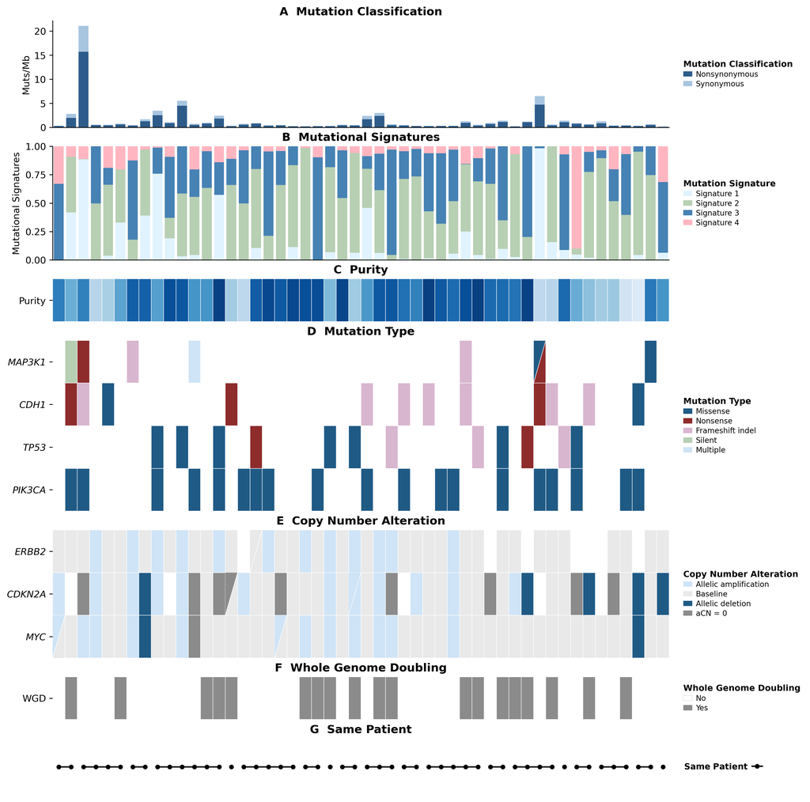

## Individual Panel Components

Each panel can also be generated independently. All panels share the same `sample_order` for proper alignment.

### Panel A: Mutation Burden

Stacked bar chart showing mutation burden per sample (Muts/Mb). Dark blue represents non-synonymous mutations, light blue represents synonymous mutations.

**Parameters:**

- `territory_bp`: Territory size in bp for normalization. Default: `60456963`
- `sample_ids`: List of sample IDs to include in specified order
- `max_samples`: Maximum samples to display. Default: `50`
- `somatic_only`: Filter to somatic variants. Default: `True`
- `pass_only`: Filter to PASS variants. Default: `True`
- `figsize`: Figure size. Default: `(14, 1.8)`

```python
py_mutation.comut_mutation_burden(
    somatic_only=False,  # TCGA LAML data doesn't have Variant_Status column
    pass_only=False,      # TCGA LAML data doesn't have FILTER column
    territory_bp=60456963,
    sample_ids=sample_order,
    max_samples=None
)
```

py_mutation.comut_mutation_burden( somatic_only=False, # TCGA LAML data doesn't have Variant_Status column pass_only=False, # TCGA LAML data doesn't have FILTER column territory_bp=60456963, sample_ids=sample_order, max_samples=None )

```
2026-10-13 14:29:31,937 | INFO | pyMut.visualizations.comut_plot | Reloading MAF with silent variants for CoMut: ../../../src/pyMut/data/examples/MAF/TCGA_test.maf
```

```
2026-10-13 14:29:34,445 | INFO | pyMut.visualizations.comut_plot | CoMut filter: kept 64,585 coding+silent variants, excluded 12,620 non-coding variants (RNA, Intron, IGR, etc.)
```

```
2026-10-13 14:29:34,509 | INFO | pyMut.visualizations.comut_plot | Removed 18,162 duplicate variants
```

```
2026-10-13 14:29:34,525 | INFO | pyMut.visualizations.comut_plot | TMB calculation: 46,423 coding variants from 46,423 total variants
```

```
2026-10-13 14:29:34,533 | INFO | pyMut.visualizations.comut_plot | Calculated TMB for 525 samples (range: 0.07-80.34 Muts/Mb)
```

```
2026-10-13 14:29:34,653 | INFO | pyMut.visualizations.comut_plot | Panel A created in 2.72s
```

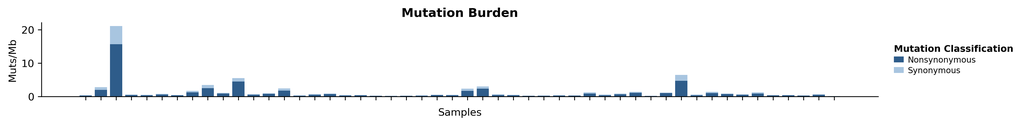

### Panel B: Mutational Signatures

Stacked bar chart showing mutational signature contributions per sample. Each bar represents 100% with colored segments for each signature.

**Parameters:**

- `signatures_tsv`: Path to TSV file with signature data
- `sample_order`: List of sample IDs for alignment
- `signature_labels`: List of signature names
- `normalize`: Normalize rows to sum to 1. Default: `True`
- `figsize`: Figure size. Default: `(12, 2.0)`

```python
py_mutation.comut_mutation_signatures_plot(
    signatures_tsv=sig_tsv_path,
    sample_order=sample_order,
    signature_labels=["Signature 1", "Signature 2", "Signature 3", "Signature 4"],
    normalize=True,
    figsize=(12, 2.0),
    title="Mutational Signatures"
)
```

py_mutation.comut_mutation_signatures_plot( signatures_tsv=sig_tsv_path, sample_order=sample_order, signature_labels=["Signature 1", "Signature 2", "Signature 3", "Signature 4"], normalize=True, figsize=(12, 2.0), title="Mutational Signatures" )

```
2026-10-13 14:29:34,972 | INFO | pyMut.visualizations.comut_plot | Panel B created in 0.17s
```

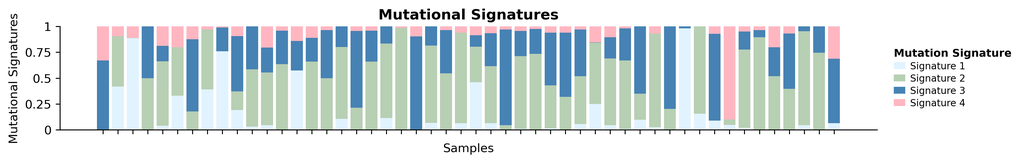

### Panel C: Tumor Purity

1-row heatmap showing tumor purity per sample. Color intensity represents the proportion of tumor cells.

**Parameters:**

- `purity_tsv`: Path to TSV file with purity data
- `sample_order`: List of sample IDs for alignment
- `figsize`: Figure size. Default: `(12, 1.5)`

```python
py_mutation.comut_purity_plot(
    purity_tsv=purity_tsv_path,
    sample_order=sample_order,
    figsize=(12, 1.2)
)
```

py_mutation.comut_purity_plot( purity_tsv=purity_tsv_path, sample_order=sample_order, figsize=(12, 1.2) )

```
2026-10-13 14:29:35,229 | INFO | pyMut.visualizations.comut_plot | Panel C created in 0.07s
```

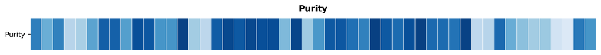

### Panel D: Mutation Type (Oncoprint)

Matrix showing mutation types across genes and samples. Cell colors indicate mutation type (Missense, Nonsense, Frameshift indel, Silent, Multiple).

**Parameters:**

- `mutation_data_tsv`: Path to TSV file with mutation data
- `sample_order`: List of sample IDs for alignment
- `gene_order`: List of gene names (top to bottom)
- `figsize`: Figure size. Default: `(12, 4.0)`

```python
py_mutation.comut_mutation_type_plot(
    mutation_data_tsv=mutation_data_tsv_path,
    sample_order=sample_order,
    gene_order=gene_order,
    figsize=(12, 3.2),
    title="Mutation Type"
)
```

py_mutation.comut_mutation_type_plot( mutation_data_tsv=mutation_data_tsv_path, sample_order=sample_order, gene_order=gene_order, figsize=(12, 3.2), title="Mutation Type" )

```
2026-10-13 14:29:35,563 | INFO | pyMut.visualizations.comut_plot | Panel D created in 0.26s
```

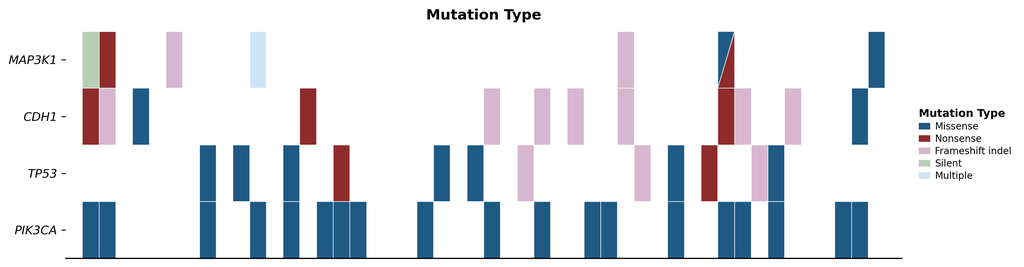

### Panel E: Copy Number Alteration

Matrix showing CNA states across genes and samples. States include Baseline, Allelic amplification, Allelic deletion, and aCN = 0 (homozygous deletion).

**Parameters:**

- `cna_tsv`: Path to TSV file with CNA data
- `sample_order`: List of sample IDs for alignment
- `gene_order`: List of gene names (top to bottom)
- `figsize`: Figure size. Default: `(12, 2.0)`

```python
py_mutation.comut_cna_plot(
    cna_tsv=cna_tsv_path,
    sample_order=sample_order,
    gene_order=cna_gene_order,
    figsize=(12, 2.0),
    title="Copy Number Alteration"
)
```

py_mutation.comut_cna_plot( cna_tsv=cna_tsv_path, sample_order=sample_order, gene_order=cna_gene_order, figsize=(12, 2.0), title="Copy Number Alteration" )

```
2026-10-13 14:29:35,942 | INFO | pyMut.visualizations.comut_plot | Panel E created in 0.25s
```

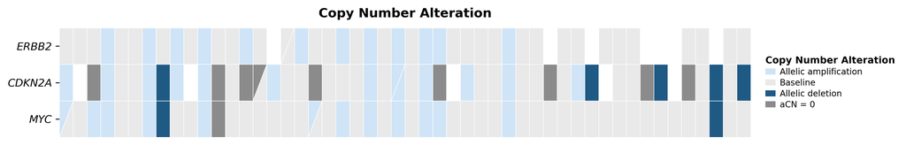

### Panel F: Whole Genome Doubling

Track showing WGD status per sample. Gray rectangles indicate WGD present.

**Parameters:**

- `wgd_tsv`: Path to TSV file with WGD data
- `sample_order`: List of sample IDs for alignment
- `figsize`: Figure size. Default: `(12, 1.2)`

```python
py_mutation.comut_wgd_plot(
    wgd_tsv=wgd_tsv_path,
    sample_order=sample_order,
    figsize=(12, 1.2)
)
```

py_mutation.comut_wgd_plot( wgd_tsv=wgd_tsv_path, sample_order=sample_order, figsize=(12, 1.2) )

```
2026-10-13 14:29:36,214 | INFO | pyMut.visualizations.comut_plot | Panel F created in 0.09s
```

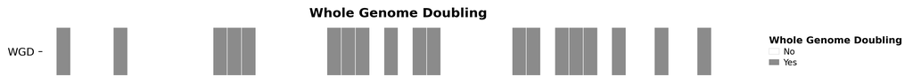

### Panel G: Same Patient

Track indicating samples from the same patient. Black dots represent samples, horizontal lines connect samples from the same patient.

**Parameters:**

- `sp_tsv`: Path to TSV file with patient grouping data
- `sample_order`: List of sample IDs for alignment
- `figsize`: Figure size. Default: `(12, 1.2)`

```python
py_mutation.comut_same_patient_plot(
    sp_tsv=sp_tsv_path,
    sample_order=sample_order,
    figsize=(12, 1.2)
)
```

py_mutation.comut_same_patient_plot( sp_tsv=sp_tsv_path, sample_order=sample_order, figsize=(12, 1.2) )

```
2026-10-13 14:29:36,385 | INFO | pyMut.visualizations.comut_plot | Panel G created in 0.07s
```

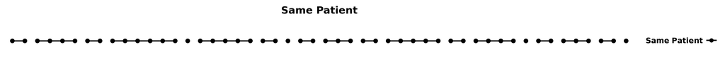